# CSE5DEV Assessment 2 Michael Le 21689299

2023-08-08

### FOR THIS ASSESSMENT I USED R VERSION 4.3.1 IN WINDOWS TO APPLY

### NESSARILY PACKAGES BELOW

```r
#Before starting the Assessment
#1. Familise with the directories
#2. Understand what the packages do, you may need to change into the
# proper version of R to ultise later in this assessment

#Packages for TASK 1
library(tidyverse)
```

```r
library(tidyr)
library(dplyr)
library(readr)
library(ggplot2)


#Packages for TASK 2
#Install the following packages below, Otherwise install the other packages
#including some dependencies.Last Resort, update the right version of R.

library(DescTools)
library(tidyselect)


library(Hmisc)
library(PerformanceAnalytics)
library(corrplot)
#GGPUBR
#Go to this link https://cran.r-project.org/web/packages/ggplot2/index.html download
#and unzip the file, I am using Windows for example (ensure to download which browser you are currently using)
#into the R directory, ensure to read which version of R you should be using
library(ggpubr)
```

#packages you have to manually install

```r
#GGPUBR
#Go to this link https://cran.r-project.org/web/packages/ggplot2/index.html download
#and unzip the file, I am using Windows for example (ensure to download which browser you are currently using)
#into the R directory, ensure to read which version of R you should be using
library(ggpubr)
```

### DATASET FOR TASK 1: STUDENT MARKS

```r
#START TASK 1A and TASK 1B
dat_smarks = read.csv("C:/Users/mikel/OneDrive/Desktop/CSE5DEV Assessment 2 Code/Datasets/Studentmarks.csv",header = TRUE)
names(dat_smarks)
```

```
## [1] "StudentID"   "Studentname" "dob"         "X2020"       "X2021"
## [6] "X2022"
```

#Step 2. Print the structure of the whole data

```r
str(dat_smarks)
```

```
## 'data.frame':    10 obs. of  6 variables:
##  $ StudentID  : int  1 2 3 4 5 6 7 8 9 10
##  $ Studentname: chr  "Anna" "James" "Mary" "Antony" ...
##  $ dob        : chr  "12/12/1998" "10/08/1999" "21/08/1998" "02/05/1999" ...
##  $ X2020      : int  75 65 56 78 85 65 78 77 90 95
##  $ X2021      : int  78 74 68 65 78 68 52 72 87 85
##  $ X2022      : int  85 52 90 85 65 70 88 75 88 75
```

#Step 3 Print out the Student Marks dataset to understand them later when performing #further analysis. luckily we do not need to clean the data since we #have all values filled in all of the columns.

```r
dat_smarks
```

| StudentID | Studentname | dob | X2020 | X2021 | X2022 |
| --- | --- | --- | --- | --- | --- |
| 1 | Anna | 12/12/1998 | 75 | 78 | 85 |
| 2 | James | 10/08/1999 | 65 | 74 | 52 |
| 3 | Mary | 21/08/1998 | 56 | 68 | 90 |
| 4 | Antony | 02/05/1999 | 78 | 65 | 85 |
| 5 | Jacob | 22/07/1998 | 85 | 78 | 65 |
| 6 | Angelin | 11/05/1998 | 65 | 68 | 70 |
| 7 | Kellie | 19/04/1999 | 78 | 52 | 88 |
| 8 | Jesse | 27/06/1998 | 77 | 72 | 75 |
| 9 | John | 15/10/1998 | 90 | 87 | 88 |
| 10 | Therese | 06/11/1998 | 95 | 85 | 75 |

#Step 4. Check if there are any missing values within the dataset for Student Marks.

```r
#Luckily there is no missing values in the Student Mark Dataset.
summary(dat_smarks)
```

```
##    StudentID     Studentname            dob                X2020
##  Min.   : 1.00   Length:10          Length:10          Min.   :56.00
##  1st Qu.: 3.25   Class :character   Class :character   1st Qu.:67.50
##  Median : 5.50   Mode  :character   Mode  :character   Median :77.50
##  Mean   : 5.50                                         Mean   :76.40
##  3rd Qu.: 7.75                                         3rd Qu.:83.25
##  Max.   :10.00                                         Max.   :95.00
##      X2021          X2022
##  Min.   :52.0   Min.   :52.00
##  1st Qu.:68.0   1st Qu.:71.25
##  Median :73.0   Median :80.00
##  Mean   :72.7   Mean   :77.30
##  3rd Qu.:78.0   3rd Qu.:87.25
##  Max.   :87.0   Max.   :90.00
```

#Step 5. Remove all row duplicate, since they do not impact on the overall #data

```r
dat_smarks <- distinct(dat_smarks)
dat_smarks
```

| StudentID | Studentname | dob | X2020 | X2021 | X2022 |
| --- | --- | --- | --- | --- | --- |
| 1 | Anna | 12/12/1998 | 75 | 78 | 85 |
| 2 | James | 10/08/1999 | 65 | 74 | 52 |
| 3 | Mary | 21/08/1998 | 56 | 68 | 90 |
| 4 | Antony | 02/05/1999 | 78 | 65 | 85 |
| 5 | Jacob | 22/07/1998 | 85 | 78 | 65 |
| 6 | Angelin | 11/05/1998 | 65 | 68 | 70 |
| 7 | Kellie | 19/04/1999 | 78 | 52 | 88 |
| 8 | Jesse | 27/06/1998 | 77 | 72 | 75 |
| 9 | John | 15/10/1998 | 90 | 87 | 88 |
| 10 | Therese | 06/11/1998 | 95 | 85 | 75 |

# Step 6. We mutate and convert in Part A numeric,Part B integer and Part D integer

# to compute the columns for ages for ages1, ages 2 and total marks respectively.

```r
dat_smarks <- dat_smarks %>% mutate(
  dat_smarks, ages1 = as.numeric((Sys.Date() - as.Date(dob,format="%d/%m/%Y"))/365.25),
  ages2 = as.integer((Sys.Date() - as.Date(dob,format="%d/%m/%Y"))/365.25),
  total_marks = X2020 + X2021 + X2022)

dat_smarks
```

| StudentID | Studentname | dob | X2020 | X2021 | X2022 | ages1 | ages2 | total_marks |
| --- | --- | --- | --- | --- | --- | --- | --- | --- |
| 1 | Anna | 12/12/1998 | 75 | 78 | 85 | 24.74470 | 24 | 238 |
| 2 | James | 10/08/1999 | 65 | 74 | 52 | 24.08487 | 24 | 191 |
| 3 | Mary | 21/08/1998 | 56 | 68 | 90 | 25.05407 | 25 | 214 |
| 4 | Antony | 02/05/1999 | 78 | 65 | 85 | 24.35866 | 24 | 228 |
| 5 | Jacob | 22/07/1998 | 85 | 78 | 65 | 25.13621 | 25 | 228 |
| 6 | Angelin | 11/05/1998 | 65 | 68 | 70 | 25.33333 | 25 | 203 |
| 7 | Kellie | 19/04/1999 | 78 | 52 | 88 | 24.39425 | 24 | 218 |
| 8 | Jesse | 27/06/1998 | 77 | 72 | 75 | 25.20465 | 25 | 224 |
| 9 | John | 15/10/1998 | 90 | 87 | 88 | 24.90349 | 24 | 265 |
| 10 | Therese | 06/11/1998 | 95 | 85 | 75 | 24.84326 | 24 | 255 |

```r
#END OF TASK 1A and 1B
```

#TASK 1C #Step 1. Renaming the columns to Marks_2020, Marks_2021 and Marks_2022 to #remember which year it was marked.

```r
#Start Task 1C
dat_smarks <- dat_smarks %>% rename(Marks_2020 = X2020,Marks_2021=X2021,
                                    Marks_2022 = X2022)
dat_smarks
```

| StudentID | Studentname | dob | Marks_2020 | Marks_2021 | Marks_2022 | ages1 | ages2 | total_marks |
| --- | --- | --- | --- | --- | --- | --- | --- | --- |
| 1 | Anna | 12/12/1998 | 75 | 78 | 85 | 24.74470 | 24 | 238 |
| 2 | James | 10/08/1999 | 65 | 74 | 52 | 24.08487 | 24 | 191 |
| 3 | Mary | 21/08/1998 | 56 | 68 | 90 | 25.05407 | 25 | 214 |
| 4 | Antony | 02/05/1999 | 78 | 65 | 85 | 24.35866 | 24 | 228 |
| 5 | Jacob | 22/07/1998 | 85 | 78 | 65 | 25.13621 | 25 | 228 |
| 6 | Angelin | 11/05/1998 | 65 | 68 | 70 | 25.33333 | 25 | 203 |
| 7 | Kellie | 19/04/1999 | 78 | 52 | 88 | 24.39425 | 24 | 218 |
| 8 | Jesse | 27/06/1998 | 77 | 72 | 75 | 25.20465 | 25 | 224 |
| 9 | John | 15/10/1998 | 90 | 87 | 88 | 24.90349 | 24 | 265 |
| 10 | Therese | 06/11/1998 | 95 | 85 | 75 | 24.84326 | 24 | 255 |

#Step 2. Applying the gather function to ensure it is easlier to categorise between #Year and Mark.

```r
dat_smarks <- gather(dat_smarks,'Year','Mark',4:6)
dat_smarks
```

| StudentID | Studentname | dob | ages1 | ages2 | total_marks | Year | Mark |
| --- | --- | --- | --- | --- | --- | --- | --- |
| 1 | Anna | 12/12/1998 | 24.74470 | 24 | 238 | Marks_2020 | 75 |
| 2 | James | 10/08/1999 | 24.08487 | 24 | 191 | Marks_2020 | 65 |
| 3 | Mary | 21/08/1998 | 25.05407 | 25 | 214 | Marks_2020 | 56 |
| 4 | Antony | 02/05/1999 | 24.35866 | 24 | 228 | Marks_2020 | 78 |
| 5 | Jacob | 22/07/1998 | 25.13621 | 25 | 228 | Marks_2020 | 85 |
| 6 | Angelin | 11/05/1998 | 25.33333 | 25 | 203 | Marks_2020 | 65 |
| 7 | Kellie | 19/04/1999 | 24.39425 | 24 | 218 | Marks_2020 | 78 |
| 8 | Jesse | 27/06/1998 | 25.20465 | 25 | 224 | Marks_2020 | 77 |
| 9 | John | 15/10/1998 | 24.90349 | 24 | 265 | Marks_2020 | 90 |
| 10 | Therese | 06/11/1998 | 24.84326 | 24 | 255 | Marks_2020 | 95 |

[output cut: 20 more lines]

#Step 3. Using the seperate function to ensure we want the Year value by itself.

```r
dat_smarks <- separate(dat_smarks,Year,c('Character','Year'),sep='_')
dat_smarks
```

| StudentID | Studentname | dob | ages1 | ages2 | total_marks | Character | Year | Mark |
| --- | --- | --- | --- | --- | --- | --- | --- | --- |
| 1 | Anna | 12/12/1998 | 24.74470 | 24 | 238 | Marks | 2020 | 75 |
| 2 | James | 10/08/1999 | 24.08487 | 24 | 191 | Marks | 2020 | 65 |
| 3 | Mary | 21/08/1998 | 25.05407 | 25 | 214 | Marks | 2020 | 56 |
| 4 | Antony | 02/05/1999 | 24.35866 | 24 | 228 | Marks | 2020 | 78 |
| 5 | Jacob | 22/07/1998 | 25.13621 | 25 | 228 | Marks | 2020 | 85 |
| 6 | Angelin | 11/05/1998 | 25.33333 | 25 | 203 | Marks | 2020 | 65 |
| 7 | Kellie | 19/04/1999 | 24.39425 | 24 | 218 | Marks | 2020 | 78 |
| 8 | Jesse | 27/06/1998 | 25.20465 | 25 | 224 | Marks | 2020 | 77 |
| 9 | John | 15/10/1998 | 24.90349 | 24 | 265 | Marks | 2020 | 90 |
| 10 | Therese | 06/11/1998 | 24.84326 | 24 | 255 | Marks | 2020 | 95 |

[output cut: 20 more lines]

#Step 4. We want to remove the Character to avoid reduancy in the student dataset.

```r
dat_smarks <- dat_smarks %>% select(-Character)
dat_smarks
```

| StudentID | Studentname | dob | ages1 | ages2 | total_marks | Year | Mark |
| --- | --- | --- | --- | --- | --- | --- | --- |
| 1 | Anna | 12/12/1998 | 24.74470 | 24 | 238 | 2020 | 75 |
| 2 | James | 10/08/1999 | 24.08487 | 24 | 191 | 2020 | 65 |
| 3 | Mary | 21/08/1998 | 25.05407 | 25 | 214 | 2020 | 56 |
| 4 | Antony | 02/05/1999 | 24.35866 | 24 | 228 | 2020 | 78 |
| 5 | Jacob | 22/07/1998 | 25.13621 | 25 | 228 | 2020 | 85 |
| 6 | Angelin | 11/05/1998 | 25.33333 | 25 | 203 | 2020 | 65 |
| 7 | Kellie | 19/04/1999 | 24.39425 | 24 | 218 | 2020 | 78 |
| 8 | Jesse | 27/06/1998 | 25.20465 | 25 | 224 | 2020 | 77 |
| 9 | John | 15/10/1998 | 24.90349 | 24 | 265 | 2020 | 90 |
| 10 | Therese | 06/11/1998 | 24.84326 | 24 | 255 | 2020 | 95 |

[output cut: 20 more lines]

#Step 5. Using the Scatterplot using geom point() grouped by Year for #C. Create a scatter plot for Studentname versus Marks of all three years.

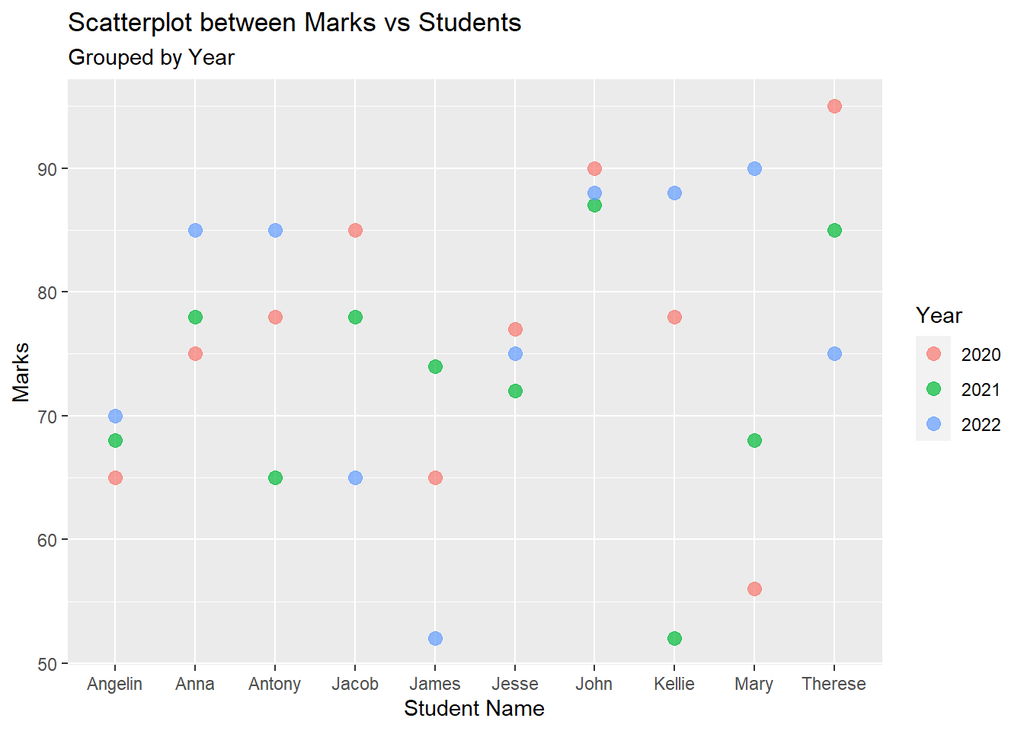

```r
#END TASK 1C
ggplot (data = dat_smarks, mapping = aes(x = Studentname,y=Mark,col=Year)) + geom_point (alpha = .7,
size = 3)  + labs(title = 'Scatterplot between Marks vs Students',subtitle = 'Grouped by Year', x= 'Student Name', y= 'Marks')
```

#TASK 1D #Step 1.We want to filter the who got at least 200 marks in total and create a bar chart for students vs totalmarks in the descending order of their marks.

[figure not shown]

```r
#START TASK 1D
dat_smarks_atl200 <- dat_smarks %>% filter(total_marks >=200)
dat_smarks_atl200 <- dat_smarks_atl200 %>% arrange(desc(total_marks))
ggplot(dat_smarks_atl200, aes(x= reorder(Studentname,-total_marks),y=total_marks)) + geom_bar(stat="identity", color='red',fill='red') + labs(title = 'Bar chart of Students who scored 200 or more',subtitle = 'in descending Order', x= 'Student Name', y= 'Total Mark')
```

```r
#END TASK 1D
```

### TASK 2: DATASET MOVIES

#Data visualisation section

#Step 1.Import data into RStudio #In this case, were given the required datasets. #MobliePhoneData, Movies and Studentmarks.

#TASK 2A #Set the directory first, to locate your datasets

```r
#Start Task 2A
setwd("C:/Users/mikel/OneDrive/Desktop/CSE5DEV Assessment 2 Code/Datasets")
```

#Step 2. Were are now performing some data wrangling, by #opening one of the datasets from the folder, #For instance we use the #data for Movies

```r
dat_mov = read.csv("C:/Users/mikel/OneDrive/Desktop/CSE5DEV Assessment 2 Code/Datasets/Movies.csv",header = TRUE)
```

#Step 3. Check the name function to print the name of columns.

```r
names(dat_mov)
```

```
##  [1] "Color"                     "Director"
##  [3] "Reviews"                   "Duration"
##  [5] "Director_facebook_likes"   "Actor_3_facebook_likes"
##  [7] "Actor_2_name"              "Actor_1_facebook_likes"
##  [9] "Gross"                     "Genre"
## [11] "Actor_1_name"              "Title"
## [13] "Votes"                     "Cast_total_facebook_likes"
## [15] "Actor_3_name"              "Facenumber_in_poster"
## [17] "Plot_keywords"             "Movie_imdb_link"
## [19] "Language"                  "Content_rating"
## [21] "Budget"                    "Year"
## [23] "Actor_2_facebook_likes"    "Imdb_score"
## [25] "Aspect_ratio"              "Movie_facebook_likes"
```

#Step 4. Check the head of the dataset for Movies for observation

```r
head(dat_mov)
```

|  | Color | Director | Reviews | Duration | Director_facebook_likes | Actor_3_facebook_likes | Actor_2_name | Actor_1_facebook_likes | Gross | Genre | Actor_1_name | Title | Votes | Cast_total_facebook_likes | Actor_3_name | Facenumber_in_poster | Plot_keywords | Movie_imdb_link | Language | Content_rating | Budget | Year | Actor_2_facebook_likes | Imdb_score | Aspect_ratio | Movie_facebook_likes |
| --- | --- | --- | --- | --- | --- | --- | --- | --- | --- | --- | --- | --- | --- | --- | --- | --- | --- | --- | --- | --- | --- | --- | --- | --- | --- | --- |
| 1 | Color | James Cameron | 723 | 178 | 0 | 855 | Joel David Moore | 1000 | 760505847 | Action | CCH Pounder | Avatara | 886204 | 2791 | Wes Studi | 0 | avatar\|future\|marine\|native\|paraplegic | http://www.imdb.com/title/tt0499549/?ref_=fn_tt_tt_1 | English | PG-13 | 237000000 | 2009 | 936 | 7.9 | 1.78 | 33000 |
| 2 | Color | Gore Verbinski | 302 | 169 | 563 | 1000 | Orlando Bloom | 40000 | 309404152 | Action | Johnny Depp | Pirates of the Caribbean: At World's Enda | 471220 | 46563 | Jack Davenport | 0 | goddess\|marriage ceremony\|marriage proposal\|pirate\|singapore | http://www.imdb.com/title/tt0449088/?ref_=fn_tt_tt_1 | English |  | 300000000 | 2007 | 5000 | 7.1 | 2.35 | 0 |
| 3 | Color | Sam Mendes | 602 | 148 | 0 | 161 | Rory Kinnear | 11000 | 200074175 | Action | Christoph Waltz | Spectrea | 275868 | 11554 | Stephanie Sigman | 1 | bomb\|espionage\|sequel\|spy\|terrorist | http://www.imdb.com/title/tt2379713/?ref_=fn_tt_tt_1 | English | PG-13 | 245000000 | 2015 | 393 | 6.8 | 2.35 | 85000 |
| 4 | Color | Christopher Nolan | 813 | 164 | 22000 | 23000 | Christian Bale | 27000 | 448130642 | Action | Tom Hardy | The Dark Knight Risesa | 1144337 | 95000 | Joseph Gordon-Levitt | 0 | deception\|imprisonment\|lawlessness\|police officer\|terrorist plot | http://www.imdb.com/title/tt1345836/?ref_=fn_tt_tt_1 | English | PG-13 | 250000000 | 2012 | 23000 | 8.5 | 2.35 | 164000 |
| 5 | Color | Andrew Stanton | 462 | 132 | 475 | 530 | Samantha Morton | 640 | 73058679 | Action | Daryl Sabara | John Cartera | 212204 | 2277 | Polly Walker | 1 | alien\|american civil war\|male nipple\|mars\|princess | http://www.imdb.com/title/tt0401729/?ref_=fn_tt_tt_1 | English | PG-13 | 263700000 | 2012 | 632 | 6.6 | 2.35 | 24000 |
| 6 | Color | Sam Raimi | 392 | 156 | 0 | 4000 | James Franco | 24000 | 336530303 | Action | J.K. Simmons | Spider-Man 3a | 383056 | 39000 | Kirsten Dunst | 0 | sandman\|spider man\|symbiote\|venom\|villain | http://www.imdb.com/title/tt0413300/?ref_=fn_tt_tt_1 | English | PG-13 | 258000000 | 2007 | 11000 | 6.2 | 2.35 | 0 |

#Step 5. Observe if there any missing values for the dataset for Movies.

```r
summary(dat_mov)
```

```
##     Color             Director            Reviews          Duration
##  Length:3891        Length:3891        Min.   :  1.00   Min.   : 34.0
##  Class :character   Class :character   1st Qu.: 72.25   1st Qu.: 95.0
##  Mode  :character   Mode  :character   Median :134.00   Median :106.0
##                                        Mean   :163.23   Mean   :109.9
##                                        3rd Qu.:221.75   3rd Qu.:120.0
##                                        Max.   :813.00   Max.   :330.0
##                                        NA's   :1        NA's   :1
##  Director_facebook_likes Actor_3_facebook_likes Actor_2_name
##  Min.   :    0.0         Min.   :    0.0        Length:3891
##  1st Qu.:   10.0         1st Qu.:  183.0        Class :character
##  Median :   58.0         Median :  427.0        Mode  :character
##  Mean   :  781.3         Mean   :  753.5
##  3rd Qu.:  226.0         3rd Qu.:  687.0
##  Max.   :23000.0         Max.   :23000.0
##                          NA's   :10
##  Actor_1_facebook_likes     Gross              Genre
##  Min.   :     0.0       Min.   :      162   Length:3891
##  1st Qu.:   721.8       1st Qu.:  6836508   Class :character
##  Median :  1000.0       Median : 27979400   Mode  :character
##  Mean   :  7584.7       Mean   : 51054995
##  3rd Qu.: 12000.0       3rd Qu.: 65360661
##  Max.   :640000.0       Max.   :760505847
##  NA's   :3
##  Actor_1_name          Title               Votes
##  Length:3891        Length:3891        Min.   :      5
##  Class :character   Class :character   1st Qu.:  17314
##  Mode  :character   Mode  :character   Median :  50415
##                                        Mean   : 102583
##                                        3rd Qu.: 124204
##                                        Max.   :1689764
##
##  Cast_total_facebook_likes Actor_3_name       Facenumber_in_poster
##  Min.   :     0            Length:3891        Min.   : 0.00
##  1st Qu.:  1580            Class :character   1st Qu.: 0.00
##  Median :  2886            Mode  :character   Median : 1.00
##  Mean   : 11080                               Mean   : 1.38
##  3rd Qu.: 15672                               3rd Qu.: 2.00
##  Max.   :655285                               Max.   :43.00
##                                               NA's   :6
```

[output cut: 9 more lines]

```
##  Min.   :2.180e+02   Min.   :1920   Min.   :     0         Min.   :1.600
##  1st Qu.:1.000e+07   1st Qu.:1999   1st Qu.:   363         1st Qu.:5.900
##  Median :2.400e+07   Median :2005   Median :   664         Median :6.600
##  Mean   :4.521e+07   Mean   :2003   Mean   :  1971         Mean   :6.464
##  3rd Qu.:5.000e+07   3rd Qu.:2010   3rd Qu.:   971         3rd Qu.:7.200
##  Max.   :1.222e+10   Max.   :2016   Max.   :137000         Max.   :9.300
##                                     NA's   :5
##   Aspect_ratio   Movie_facebook_likes
##  Min.   : 1.18   Min.   :     0
##  1st Qu.: 1.85   1st Qu.:     0
##  Median : 2.35   Median :   209
##  Mean   : 2.11   Mean   :  9138
##  3rd Qu.: 2.35   3rd Qu.: 11000
##  Max.   :16.00   Max.   :349000
##  NA's   :75
```

#Step 6. Count how many missing values overall movie dataset.

```r
#Counting the missing values for data-set movies
#there is 101 in total.
sum(is.na(dat_mov))
```

```
## [1] 101
```

#Step 7. Missing values for all the columns we will compute or delete rows #Only if it has impact on the overall Movie data

```r
#Total missing values for Reviews
sum(is.na(dat_mov$Reviews))
```

```
## [1] 1
```

```r
#Total missing values for Duration
sum(is.na(dat_mov$Duration))
```

```
## [1] 1
```

```r
#Total missing values for Actor_3_facebook_likes
sum(is.na(dat_mov$Actor_3_facebook_likes))
```

```
## [1] 10
```

```r
#Total missing values for Actor_1_facebook_likes
sum(is.na(dat_mov$Actor_1_facebook_likes))
```

```
## [1] 3
```

```r
#Total missing values for Facenumber_in_poster
sum(is.na(dat_mov$Facenumber_in_poster))
```

```
## [1] 6
```

```r
#Total missing values for Actor_2_facebook_likes
sum(is.na(dat_mov$Actor_2_facebook_likes))
```

```
## [1] 5
```

```r
#Total missing values for Aspect_ratio
sum(is.na(dat_mov$Aspect_ratio))
```

```
## [1] 75
```

#Step 8. Remove all row duplicate, since they do not impact on the overall #data

```r
dat_mov <- distinct(dat_mov)
dat_mov
```

| Color | Director | Reviews | Duration | Director_facebook_likes | Actor_3_facebook_likes | Actor_2_name | Actor_1_facebook_likes | Gross | Genre | Actor_1_name | Title | Votes | Cast_total_facebook_likes | Actor_3_name | Facenumber_in_poster | Plot_keywords | Movie_imdb_link | Language | Content_rating | Budget | Year | Actor_2_facebook_likes | Imdb_score | Aspect_ratio | Movie_facebook_likes |
| --- | --- | --- | --- | --- | --- | --- | --- | --- | --- | --- | --- | --- | --- | --- | --- | --- | --- | --- | --- | --- | --- | --- | --- | --- | --- |
| Color | James Cameron | 723 | 178 | 0 | 855 | Joel David Moore | 1000 | 760505847 | Action | CCH Pounder | Avatara | 886204 | 2791 | Wes Studi | 0 | avatar\|future\|marine\|native\|paraplegic | http://www.imdb.com/title/tt0499549/?ref_=fn_tt_tt_1 | English | PG-13 | 237000000 | 2009 | 936 | 7.9 | 1.78 | 33000 |
| Color | Gore Verbinski | 302 | 169 | 563 | 1000 | Orlando Bloom | 40000 | 309404152 | Action | Johnny Depp | Pirates of the Caribbean: At World's Enda | 471220 | 46563 | Jack Davenport | 0 | goddess\|marriage ceremony\|marriage proposal\|pirate\|singapore | http://www.imdb.com/title/tt0449088/?ref_=fn_tt_tt_1 | English |  | 300000000 | 2007 | 5000 | 7.1 | 2.35 | 0 |
| Color | Sam Mendes | 602 | 148 | 0 | 161 | Rory Kinnear | 11000 | 200074175 | Action | Christoph Waltz | Spectrea | 275868 | 11554 | Stephanie Sigman | 1 | bomb\|espionage\|sequel\|spy\|terrorist | http://www.imdb.com/title/tt2379713/?ref_=fn_tt_tt_1 | English | PG-13 | 245000000 | 2015 | 393 | 6.8 | 2.35 | 85000 |
| Color | Christopher Nolan | 813 | 164 | 22000 | 23000 | Christian Bale | 27000 | 448130642 | Action | Tom Hardy | The Dark Knight Risesa | 1144337 | 95000 | Joseph Gordon-Levitt | 0 | deception\|imprisonment\|lawlessness\|police officer\|terrorist plot | http://www.imdb.com/title/tt1345836/?ref_=fn_tt_tt_1 | English | PG-13 | 250000000 | 2012 | 23000 | 8.5 | 2.35 | 164000 |
| Color | Andrew Stanton | 462 | 132 | 475 | 530 | Samantha Morton | 640 | 73058679 | Action | Daryl Sabara | John Cartera | 212204 | 2277 | Polly Walker | 1 | alien\|american civil war\|male nipple\|mars\|princess | http://www.imdb.com/title/tt0401729/?ref_=fn_tt_tt_1 | English | PG-13 | 263700000 | 2012 | 632 | 6.6 | 2.35 | 24000 |
| Color | Sam Raimi | 392 | 156 | 0 | 4000 | James Franco | 24000 | 336530303 | Action | J.K. Simmons | Spider-Man 3a | 383056 | 39000 | Kirsten Dunst | 0 | sandman\|spider man\|symbiote\|venom\|villain | http://www.imdb.com/title/tt0413300/?ref_=fn_tt_tt_1 | English | PG-13 | 258000000 | 2007 | 11000 | 6.2 | 2.35 | 0 |
| Color | Nathan Greno | 324 | 100 | 15 | 284 | Donna Murphy | 799 | 200807262 | Adventure | Brad Garrett | Tangleda | 294810 | 1651 | M.C. Gainey | 1 | 17th century\|based on fairy tale\|disney\|flower\|tower | http://www.imdb.com/title/tt0398286/?ref_=fn_tt_tt_1 | English | PG | 260000000 | 2010 | 553 | 7.8 | 1.85 | 29000 |
| Color | Joss Whedon | 635 | 141 | 0 | 19000 | Robert Downey Jr. | 26000 | 458991599 | Action | Chris Hemsworth | Avengers: Age of Ultrona | 462669 | 66000 | Scarlett Johansson | 4 | artificial intelligence\|based on comic book\|captain america\|marvel cinematic universe\|superhero | http://www.imdb.com/title/tt2395427/?ref_=fn_tt_tt_1 | English | PG-13 | 250000000 | 2015 | 21000 | 7.5 | 2.35 | 118000 |
| Color | David Yates | 375 | 153 | 282 | 10000 | Daniel Radcliffe | 25000 | 301956980 | Adventure | Alan Rickman | Harry Potter and the Half-Blood Princea | 321795 | 46282 | Rupert Grint | 3 | blood\|book\|love\|potion\|professor | http://www.imdb.com/title/tt0417741/?ref_=fn_tt_tt_1 | English | PG | 250000000 | 2009 | 11000 | 7.5 | 2.35 | 10000 |
| Color | Zack Snyder | 673 | 183 | 0 | 2000 | Lauren Cohan | 15000 | 330249062 | Action | Henry Cavill | Batman v Superman: Dawn of Justicea | 371639 | 21000 | Alan D. Purwin | 0 | based on comic book\|batman\|sequel to a reboot\|superhero\|superman | http://www.imdb.com/title/tt2975590/?ref_=fn_tt_tt_1 | English | PG-13 | 250000000 | 2016 | 4000 | 6.9 | 2.35 | 197000 |

[output cut: 3846 more lines]

#STEP 9. If you decide to impute missing values #Step 9a, Take the mean() of all missing columns #Step 9b, Take the median() of all missing columns #Step 9c, Take the Mode() of all missing columns

#NOTE: If you decide not to impute the data if and only, #Option 1. Remove all rows or columns consist missing values, Proceed to Step 10. #Option 2. DO NOTHING Proceed to Step 12.

#Step 9a. Impute all the missing values by taking the means #for each columns of missing data

```r
dat_mov$Reviews[dat_mov$Reviews == mean(dat_mov$Reviews)] <- NA
dat_mov$Duration[dat_mov$Duration==mean(dat_mov$Duration)] <- NA
dat_mov$Actor_3_facebook_likes[dat_mov$Actor_3_facebook_likes==mean(dat_mov$Actor_3_facebook_likes)] <- NA
dat_mov$Actor_1_facebook_likes[dat_mov$Actor_1_facebook_likes==mean(dat_mov$Actor_1_facebook_likes)] <- NA
dat_mov$Facenumber_in_poster[dat_mov$Facenumber_in_poster==mean(dat_mov$Facenumber_in_poster)] <- NA
dat_mov$Actor_2_facebook_likes[dat_mov$Actor_2_facebook_likes==mean(dat_mov$Actor_2_facebook_likes)] <- NA
dat_mov$Aspect_ratio[dat_mov$Aspect_ratio==mean(dat_mov$Aspect_ratio)] <- NA
```

#Step 9b. Impute all the missing values by taking the medians #for each columns of missing data (CHOSEN THIS ONE)

```r
dat_mov$Reviews[dat_mov$Reviews == median(dat_mov$Reviews)] <- NA
dat_mov$Duration[dat_mov$Duration==median(dat_mov$dat_mov$Duration)] <- NA
dat_mov$Actor_3_facebook_likes[dat_mov$Actor_3_facebook_likes==median(dat_mov$Actor_3_facebook_likes)] <- NA
dat_mov$Actor_1_facebook_likes[dat_mov$Actor_1_facebook_likes==median(dat_mov$Actor_1_facebook_likes)] <- NA
dat_mov$Facenumber_in_poster[dat_mov$Facenumber_in_poster==median(dat_mov$Facenumber_in_poster)] <- NA
dat_mov$Actor_2_facebook_likes[dat_mov$Actor_2_facebook_likes==median(dat_mov$Actor_2_facebook_likes)] <- NA
dat_mov$Aspect_ratio[dat_mov$Aspect_ratio==median(dat_mov$Aspect_ratio)] <- NA
```

#Step 9c. Impute all the missing values by taking the modes #for each columns of missing data

```r
dat_mov$Reviews[dat_mov$Reviews == Mode(dat_mov$Reviews)] <- NA
dat_mov$Duration[dat_mov$Duration==Mode(dat_mov$Duration)] <- NA
dat_mov$Actor_3_facebook_likes[dat_mov$Actor_3_facebook_likes==Mode(dat_mov$Actor_3_facebook_likes)] <- NA
dat_mov$Actor_1_facebook_likes[dat_mov$Actor_1_facebook_likes==Mode(dat_mov$Actor_1_facebook_likes)] <- NA
dat_mov$Facenumber_in_poster[dat_mov$Facenumber_in_poster==Mode(dat_mov$Facenumber_in_poster)] <- NA
dat_mov$Actor_2_facebook_likes[dat_mov$Actor_2_facebook_likes==Mode(dat_mov$Actor_2_facebook_likes)] <- NA
dat_mov$Aspect_ratio[dat_mov$Aspect_ratio==Mode(dat_mov$Aspect_ratio)] <- NA
```

#Step 10. We then proceed, if we confident with our new filled in Movie Dataset to omit all the #the rows.

```r
dat_mov <- na.omit(dat_mov)
```

#Step 11. Check if there is any more missing values and check the data types in the new updated data #for movies.

```r
#End of TASK 2A
summary(dat_mov)
```

```
##     Color             Director            Reviews         Duration
##  Length:3767        Length:3767        Min.   :  1.0   Min.   : 37.0
##  Class :character   Class :character   1st Qu.: 75.0   1st Qu.: 96.0
##  Mode  :character   Mode  :character   Median :137.0   Median :106.0
##                                        Mean   :165.5   Mean   :110.2
##                                        3rd Qu.:223.0   3rd Qu.:120.0
##                                        Max.   :813.0   Max.   :330.0
##  Director_facebook_likes Actor_3_facebook_likes Actor_2_name
##  Min.   :    0.0         Min.   :    0.0        Length:3767
##  1st Qu.:   11.0         1st Qu.:  186.5        Class :character
##  Median :   61.0         Median :  433.0        Mode  :character
##  Mean   :  801.2         Mean   :  757.7
##  3rd Qu.:  234.0         3rd Qu.:  688.5
##  Max.   :23000.0         Max.   :23000.0
##  Actor_1_facebook_likes     Gross              Genre
##  Min.   :     0.0       Min.   :      162   Length:3767
##  1st Qu.:   733.5       1st Qu.:  7569033   Class :character
##  Median :  1000.0       Median : 29077547   Mode  :character
##  Mean   :  7666.3       Mean   : 51880069
##  3rd Qu.: 12500.0       3rd Qu.: 66467344
##  Max.   :640000.0       Max.   :760505847
##  Actor_1_name          Title               Votes
##  Length:3767        Length:3767        Min.   :      5
##  Class :character   Class :character   1st Qu.:  18767
##  Mode  :character   Mode  :character   Median :  53053
##                                        Mean   : 104418
##                                        3rd Qu.: 126912
##                                        Max.   :1689764
##  Cast_total_facebook_likes Actor_3_name       Facenumber_in_poster
##  Min.   :     4            Length:3767        Min.   : 0.000
##  1st Qu.:  1618            Class :character   1st Qu.: 0.000
##  Median :  2951            Mode  :character   Median : 1.000
##  Mean   : 11217                               Mean   : 1.378
##  3rd Qu.: 15804                               3rd Qu.: 2.000
##  Max.   :655285                               Max.   :43.000
##  Plot_keywords      Movie_imdb_link      Language         Content_rating
##  Length:3767        Length:3767        Length:3767        Length:3767
##  Class :character   Class :character   Class :character   Class :character
##  Mode  :character   Mode  :character   Mode  :character   Mode  :character
##
##
##
##      Budget               Year      Actor_2_facebook_likes   Imdb_score
##  Min.   :2.180e+02   Min.   :1920   Min.   :     0         Min.   :1.600
##  1st Qu.:1.000e+07   1st Qu.:1999   1st Qu.:   372         1st Qu.:5.900
##  Median :2.500e+07   Median :2005   Median :   678         Median :6.600
##  Mean   :4.585e+07   Mean   :2003   Mean   :  1992         Mean   :6.467
##  3rd Qu.:5.000e+07   3rd Qu.:2010   3rd Qu.:   974         3rd Qu.:7.200
##  Max.   :1.222e+10   Max.   :2016   Max.   :137000         Max.   :9.300
##   Aspect_ratio   Movie_facebook_likes
##  Min.   : 1.18   Min.   :     0
##  1st Qu.: 1.85   1st Qu.:     0
##  Median : 2.35   Median :   217
##  Mean   : 2.11   Mean   :  9210
##  3rd Qu.: 2.35   3rd Qu.: 11000
##  Max.   :16.00   Max.   :349000
```

```r
str(dat_mov)
```

```
## 'data.frame':    3767 obs. of  26 variables:
##  $ Color                    : chr  "Color" "Color" "Color" "Color" ...
##  $ Director                 : chr  "James Cameron" "Gore Verbinski" "Sam Mendes" "Christopher Nolan" ...
##  $ Reviews                  : int  723 302 602 813 462 392 324 635 375 673 ...
##  $ Duration                 : int  178 169 148 164 132 156 100 141 153 183 ...
##  $ Director_facebook_likes  : int  0 563 0 22000 475 0 15 0 282 0 ...
##  $ Actor_3_facebook_likes   : int  855 1000 161 23000 530 4000 284 19000 10000 2000 ...
##  $ Actor_2_name             : chr  "Joel David Moore" "Orlando Bloom" "Rory Kinnear" "Christian Bale" ...
##  $ Actor_1_facebook_likes   : int  1000 40000 11000 27000 640 24000 799 26000 25000 15000 ...
##  $ Gross                    : int  760505847 309404152 200074175 448130642 73058679 336530303 200807262 458991599 301956980 330249062 ...
##  $ Genre                    : chr  "Action" "Action" "Action" "Action" ...
##  $ Actor_1_name             : chr  "CCH Pounder" "Johnny Depp" "Christoph Waltz" "Tom Hardy" ...
##  $ Title                    : chr  "Avatara" "Pirates of the Caribbean: At World's Enda" "Spectrea" "The Dark Knight Risesa" ...
##  $ Votes                    : int  886204 471220 275868 1144337 212204 383056 294810 462669 321795 371639 ...
##  $ Cast_total_facebook_likes: int  2791 46563 11554 95000 2277 39000 1651 66000 46282 21000 ...
##  $ Actor_3_name             : chr  "Wes Studi" "Jack Davenport" "Stephanie Sigman" "Joseph Gordon-Levitt" ...
##  $ Facenumber_in_poster     : int  0 0 1 0 1 0 1 4 3 0 ...
##  $ Plot_keywords            : chr  "avatar|future|marine|native|paraplegic" "goddess|marriage ceremony|marriage proposal|pirate|singapore" "bomb|espionage|sequel|spy|terrorist" "deception|imprisonment|lawlessness|police officer|terrorist plot" ...
##  $ Movie_imdb_link          : chr  "http://www.imdb.com/title/tt0499549/?ref_=fn_tt_tt_1" "http://www.imdb.com/title/tt0449088/?ref_=fn_tt_tt_1" "http://www.imdb.com/title/tt2379713/?ref_=fn_tt_tt_1" "http://www.imdb.com/title/tt1345836/?ref_=fn_tt_tt_1" ...
##  $ Language                 : chr  "English" "English" "English" "English" ...
##  $ Content_rating           : chr  "PG-13" "" "PG-13" "PG-13" ...
##  $ Budget                   : num  2.37e+08 3.00e+08 2.45e+08 2.50e+08 2.64e+08 ...
##  $ Year                     : int  2009 2007 2015 2012 2012 2007 2010 2015 2009 2016 ...
##  $ Actor_2_facebook_likes   : int  936 5000 393 23000 632 11000 553 21000 11000 4000 ...
##  $ Imdb_score               : num  7.9 7.1 6.8 8.5 6.6 6.2 7.8 7.5 7.5 6.9 ...
##  $ Aspect_ratio             : num  1.78 2.35 2.35 2.35 2.35 2.35 1.85 2.35 2.35 2.35 ...
##  $ Movie_facebook_likes     : int  33000 0 85000 164000 24000 0 29000 118000 10000 197000 ...
##  - attr(*, "na.action")= 'omit' Named int [1:89] 96 238 593 1656 1805 1886 2010 2061 2145 2294 ...
##   ..- attr(*, "names")= chr [1:89] "96" "238" "593" "1656" ...
```

#TASK 2B. #Step 1. Based on the Dataset, calculate “Profit” and determine the relationship between #“Profit” and other variables (e.g. IMDB score). Hint: Profit = Gross – Budget. Use line #plot or scatter plot to find the relationship. Present a summary of your findings

```r
#Starting TASK 2B.
dat_mov <- dat_mov %>% mutate(dat_mov,Profit =Gross-Budget)
```

#Step 2. #Plot all the nessarily ggplots scatterplots for profit vs (Imdb score, reviews,votes and Movie facebook likes)

```r
#1.ggplot between Imdb_score vs. Profit
g1 <- ggplot(data = dat_mov, mapping = aes(x = Imdb_score ,y=Profit)) + geom_point (alpha = .7, size = 3) + labs(title = 'Imdb Score vs Profit',x='Imdb Score',y='Profit')

#2.ggplot between Reviews vs. Profit
g2<-ggplot(data = dat_mov, mapping = aes(x = Reviews,y=Profit)) + geom_point (alpha = .7, size = 3) + labs(title = 'Reviews vs Profit',x='Reviews',y='Profit')

#3.ggplot between Votes vs. Profit
g3<-ggplot(data = dat_mov, mapping = aes(x = Votes,y=Profit)) + geom_point (alpha = .7, size = 3) + labs(title = 'Votes vs Profit',x='Reviews',y='Profit')

#4.ggplot between Movie Facebook Likes vs. Profit
g4<-ggplot(data = dat_mov, mapping = aes(x = Movie_facebook_likes,y=Profit)) + geom_point (alpha = .7, size = 3) + labs(title = ' Movie facebook likes vs Profit',x='Movie facebook likes',y='Profit')
```

#Step 3. Keep all ggplots into 1 Figure.

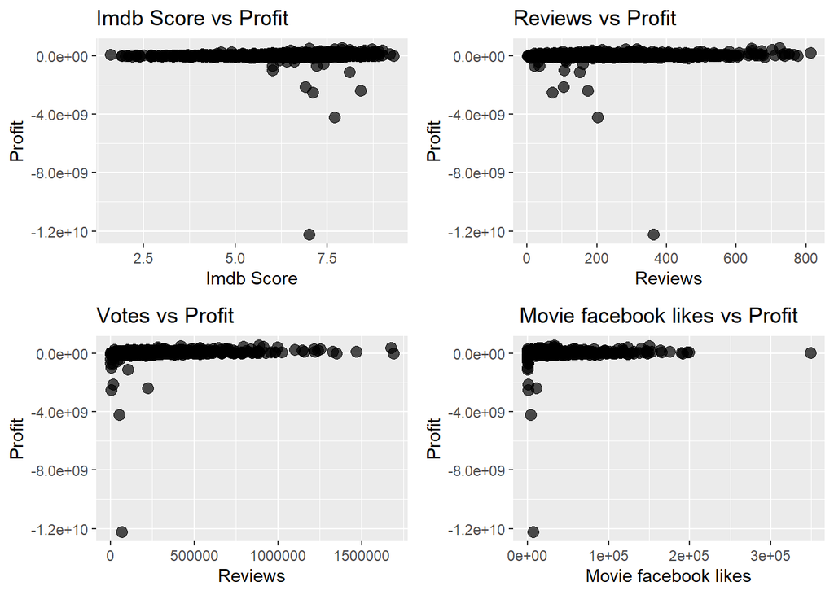

```r
#End of Part B
figure <- ggarrange(g1,g2,g3,g4,nrow=2,align="h",widths = c(1,1,1),ncol=2,heights=c(1,1,1))
figure
```

#TASK 2C #Step 1. Calculate the correlation between the relevant variable(s) used in the Dataset. #Present a summary of your findings

```r
str(dat_mov)
```

```
## 'data.frame':    3767 obs. of  27 variables:
##  $ Color                    : chr  "Color" "Color" "Color" "Color" ...
##  $ Director                 : chr  "James Cameron" "Gore Verbinski" "Sam Mendes" "Christopher Nolan" ...
##  $ Reviews                  : int  723 302 602 813 462 392 324 635 375 673 ...
##  $ Duration                 : int  178 169 148 164 132 156 100 141 153 183 ...
##  $ Director_facebook_likes  : int  0 563 0 22000 475 0 15 0 282 0 ...
##  $ Actor_3_facebook_likes   : int  855 1000 161 23000 530 4000 284 19000 10000 2000 ...
##  $ Actor_2_name             : chr  "Joel David Moore" "Orlando Bloom" "Rory Kinnear" "Christian Bale" ...
##  $ Actor_1_facebook_likes   : int  1000 40000 11000 27000 640 24000 799 26000 25000 15000 ...
##  $ Gross                    : int  760505847 309404152 200074175 448130642 73058679 336530303 200807262 458991599 301956980 330249062 ...
##  $ Genre                    : chr  "Action" "Action" "Action" "Action" ...
##  $ Actor_1_name             : chr  "CCH Pounder" "Johnny Depp" "Christoph Waltz" "Tom Hardy" ...
##  $ Title                    : chr  "Avatara" "Pirates of the Caribbean: At World's Enda" "Spectrea" "The Dark Knight Risesa" ...
##  $ Votes                    : int  886204 471220 275868 1144337 212204 383056 294810 462669 321795 371639 ...
##  $ Cast_total_facebook_likes: int  2791 46563 11554 95000 2277 39000 1651 66000 46282 21000 ...
##  $ Actor_3_name             : chr  "Wes Studi" "Jack Davenport" "Stephanie Sigman" "Joseph Gordon-Levitt" ...
##  $ Facenumber_in_poster     : int  0 0 1 0 1 0 1 4 3 0 ...
##  $ Plot_keywords            : chr  "avatar|future|marine|native|paraplegic" "goddess|marriage ceremony|marriage proposal|pirate|singapore" "bomb|espionage|sequel|spy|terrorist" "deception|imprisonment|lawlessness|police officer|terrorist plot" ...
##  $ Movie_imdb_link          : chr  "http://www.imdb.com/title/tt0499549/?ref_=fn_tt_tt_1" "http://www.imdb.com/title/tt0449088/?ref_=fn_tt_tt_1" "http://www.imdb.com/title/tt2379713/?ref_=fn_tt_tt_1" "http://www.imdb.com/title/tt1345836/?ref_=fn_tt_tt_1" ...
##  $ Language                 : chr  "English" "English" "English" "English" ...
##  $ Content_rating           : chr  "PG-13" "" "PG-13" "PG-13" ...
##  $ Budget                   : num  2.37e+08 3.00e+08 2.45e+08 2.50e+08 2.64e+08 ...
##  $ Year                     : int  2009 2007 2015 2012 2012 2007 2010 2015 2009 2016 ...
##  $ Actor_2_facebook_likes   : int  936 5000 393 23000 632 11000 553 21000 11000 4000 ...
##  $ Imdb_score               : num  7.9 7.1 6.8 8.5 6.6 6.2 7.8 7.5 7.5 6.9 ...
##  $ Aspect_ratio             : num  1.78 2.35 2.35 2.35 2.35 2.35 1.85 2.35 2.35 2.35 ...
##  $ Movie_facebook_likes     : int  33000 0 85000 164000 24000 0 29000 118000 10000 197000 ...
##  $ Profit                   : num  5.24e+08 9.40e+06 -4.49e+07 1.98e+08 -1.91e+08 ...
##  - attr(*, "na.action")= 'omit' Named int [1:89] 96 238 593 1656 1805 1886 2010 2061 2145 2294 ...
##   ..- attr(*, "names")= chr [1:89] "96" "238" "593" "1656" ...
```

#Step 2. Calculate the correlation between the relevant variable(s) used in the Dataset. #Present a summary of your findings

```r
#Start of Part C
#To start were only interest in columns that has numeric
#values in the Movie Dataset

dat_mov <- dat_mov %>% select(-Color)
dat_mov <- dat_mov %>% select(-Director)
dat_mov <- dat_mov %>% select(-Actor_2_name)
dat_mov <- dat_mov %>% select(-Genre)
dat_mov <- dat_mov %>% select(-Actor_1_name)
dat_mov <- dat_mov %>% select(-Title)
dat_mov <- dat_mov %>% select(-Actor_3_name)
dat_mov <- dat_mov %>% select(-Plot_keywords)
dat_mov <- dat_mov %>% select(-Movie_imdb_link)
dat_mov <- dat_mov %>% select(-Language)
dat_mov <- dat_mov %>% select(-Content_rating)
dat_mov <- dat_mov %>% select(-Gross)
dat_mov <- dat_mov %>% select(-Reviews)
dat_mov <- dat_mov %>% select(-Duration)
dat_mov <- dat_mov %>% select(-Director_facebook_likes)
dat_mov <- dat_mov %>% select(-Actor_3_facebook_likes)
dat_mov <- dat_mov %>% select(-Actor_1_facebook_likes)
dat_mov <- dat_mov %>% select(-Votes)
dat_mov <- dat_mov %>% select(-Cast_total_facebook_likes)
dat_mov <- dat_mov %>% select(-Facenumber_in_poster)
dat_mov <- dat_mov %>% select(-Year )
dat_mov <- dat_mov %>% select(-Actor_2_facebook_likes)
dat_mov <- dat_mov %>% select(-Movie_facebook_likes)

#dat_mov <- dat_mov %>% select(-Budget)

names(dat_mov)
```

```
## [1] "Budget"       "Imdb_score"   "Aspect_ratio" "Profit"
```

```r
summary(dat_mov)
```

```
##      Budget            Imdb_score     Aspect_ratio       Profit
##  Min.   :2.180e+02   Min.   :1.600   Min.   : 1.18   Min.   :-1.221e+10
##  1st Qu.:1.000e+07   1st Qu.:5.900   1st Qu.: 1.85   1st Qu.:-1.043e+07
##  Median :2.500e+07   Median :6.600   Median : 2.35   Median : 1.205e+06
##  Mean   :4.585e+07   Mean   :6.467   Mean   : 2.11   Mean   : 6.029e+06
##  3rd Qu.:5.000e+07   3rd Qu.:7.200   3rd Qu.: 2.35   3rd Qu.: 2.529e+07
##  Max.   :1.222e+10   Max.   :9.300   Max.   :16.00   Max.   : 5.235e+08
```

#Step 3. Check if there is any numeric values?

```r
str(dat_mov)
```

```
## 'data.frame':    3767 obs. of  4 variables:
##  $ Budget      : num  2.37e+08 3.00e+08 2.45e+08 2.50e+08 2.64e+08 ...
##  $ Imdb_score  : num  7.9 7.1 6.8 8.5 6.6 6.2 7.8 7.5 7.5 6.9 ...
##  $ Aspect_ratio: num  1.78 2.35 2.35 2.35 2.35 2.35 1.85 2.35 2.35 2.35 ...
##  $ Profit      : num  5.24e+08 9.40e+06 -4.49e+07 1.98e+08 -1.91e+08 ...
##  - attr(*, "na.action")= 'omit' Named int [1:89] 96 238 593 1656 1805 1886 2010 2061 2145 2294 ...
##   ..- attr(*, "names")= chr [1:89] "96" "238" "593" "1656" ...
```

#Step 4a. Visualise the numeric variables between Profit vs. other variables using scatterplots #Using ggscatter()

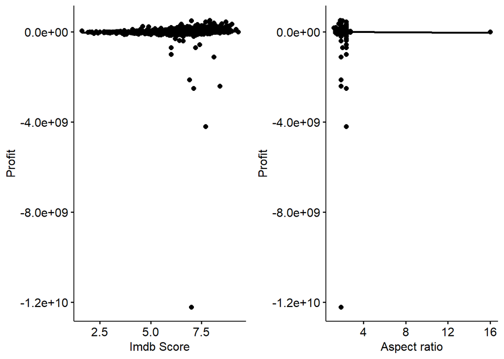

```r
#Plot 1.Imdb score vs Profit
g5 <- ggscatter(dat_mov,x="Imdb_score",y="Profit",add="reg.line",cont.int=TRUE,xlab="Imdb Score",ylab="Profit")

#Plot 2.Aspect Ratio vs Profit
g6 <- ggscatter(dat_mov,x="Aspect_ratio",y="Profit",add="reg.line",cont.int=TRUE,xlab="Aspect ratio",ylab="Profit")

#Plot 3.Budget vs Profit
g7 <- ggscatter(dat_mov,x="Budget",y="Profit",add="reg.line",cont.int=TRUE,xlab="Budget ",ylab="Profit")

#Visualise Plots 1 and 2.
figure_1 <- ggarrange(g5,g6,nrow=1,ncol=2,widths = c(1,1),align="v",heights=c(1,1))
figure_1
```

#Step 4b.Visualise Plot 3 Only

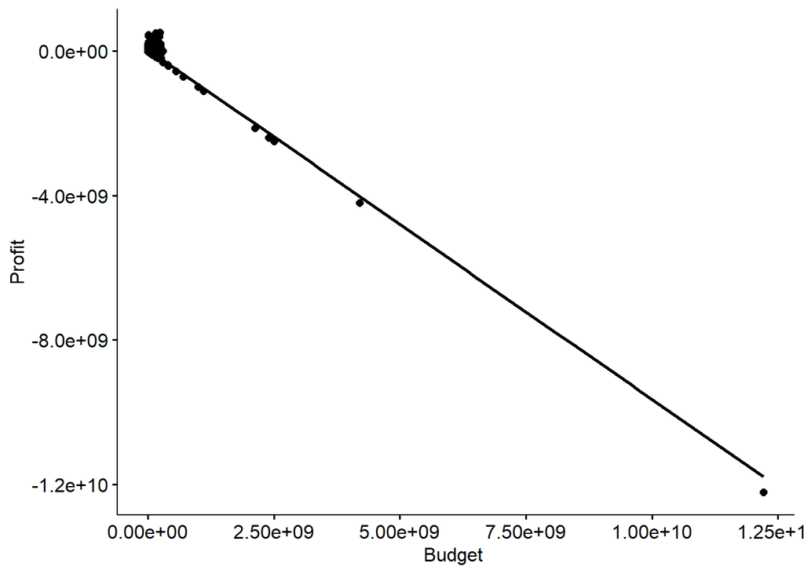

```r
#Visualise
g7
```

#Step 5a. Implement Pearson correlation, Spearman correlation and Kendall correlation #On all the scatterplots demonstrated in Steps 4a and 4b.

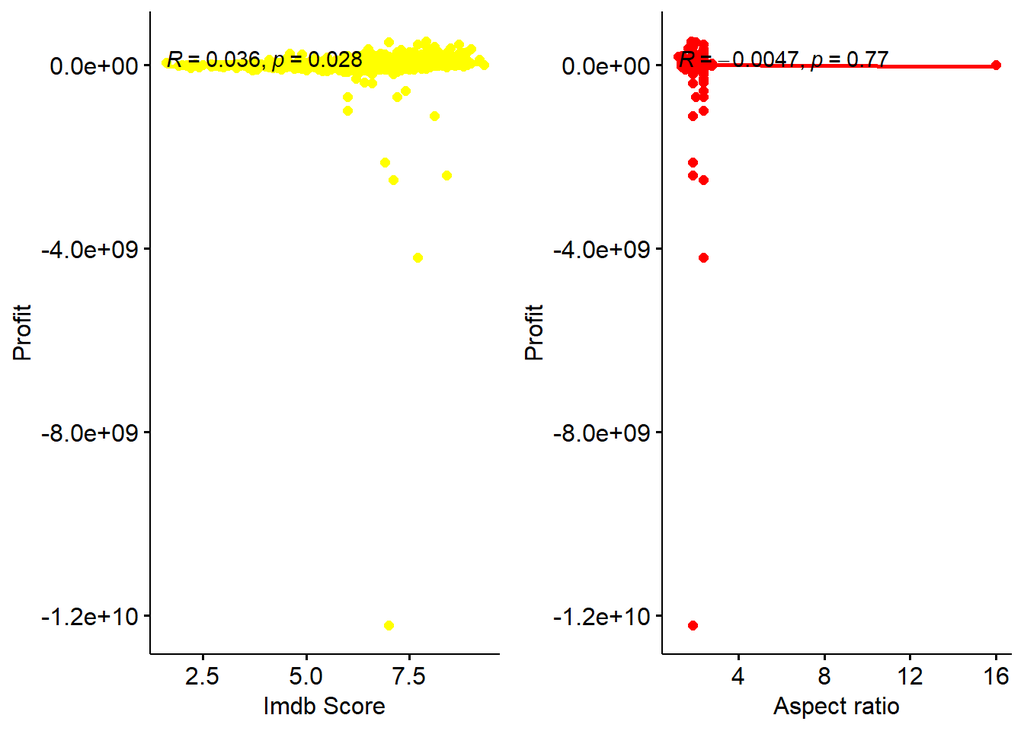

```r
#Plot 1.Imdb score vs Profit
g5 <- ggscatter(dat_mov,x="Imdb_score",y="Profit",add="reg.line",cont.int=TRUE,cor.coef=TRUE,cpr.method="pearson",xlab="Imdb Score",ylab="Profit",color="yellow")

#Plot 2.Aspect Ratio vs Profit
g6 <- ggscatter(dat_mov,x="Aspect_ratio",y="Profit",add="reg.line",cont.int=TRUE,cor.coef=TRUE,cpr.method="pearson",xlab="Aspect ratio",ylab="Profit",color="red")

#Plot 3.Budget vs Profit
g7 <- ggscatter(dat_mov,x="Budget",y="Profit",add="reg.line",cont.int=TRUE,cor.coef=TRUE,cpr.method="pearson",xlab="Budget ",ylab="Profit",color="lightblue")

#Visualise Plots 1 and 2.
figure_1 <- ggarrange(g5,g6,nrow=1,ncol=2,widths = c(1,1),align="v",heights=c(1,1))
figure_1
```

#Step 5b.Same thing for plot 3.

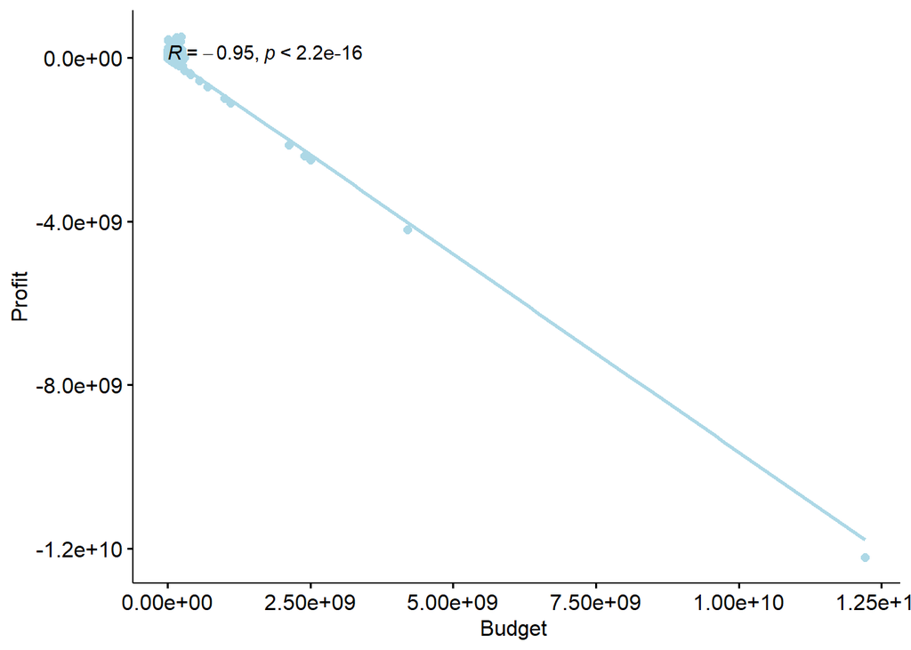

```r
g7
```

#Step 6. Apply the Shapiro-Wilk Test

#Check the normality of Profit and Budget,Imdb Score and Aspect Ratio.

```r
shapiro.test(dat_mov$Profit)
```

```
##
##  Shapiro-Wilk normality test
##
## data:  dat_mov$Profit
## W = 0.098818, p-value < 2.2e-16
```

```r
shapiro.test(dat_mov$Budget)
```

```
##
##  Shapiro-Wilk normality test
##
## data:  dat_mov$Budget
## W = 0.075488, p-value < 2.2e-16
```

```r
shapiro.test(dat_mov$Imdb_score)
```

```
##
##  Shapiro-Wilk normality test
##
## data:  dat_mov$Imdb_score
## W = 0.9727, p-value < 2.2e-16
```

```r
shapiro.test(dat_mov$Aspect_ratio)
```

```
##
##  Shapiro-Wilk normality test
##
## data:  dat_mov$Aspect_ratio
## W = 0.46903, p-value < 2.2e-16
```

#From the results, we can see that p-values are less than the significance level #0.05. This means that H1 does not get rejected. Hence, we can assume #Profit and other numeric values are not normally distributed.

#Step 7. Apply the Pearson correlation between Profit and other variables.

```r
#1. Test Between Profit and Budget
res_p1 <- cor.test(dat_mov$Profit, dat_mov$Budget, method = "pearson")
res_p1
```

```
##
##  Pearson's product-moment correlation
##
## data:  dat_mov$Profit and dat_mov$Budget
## t = -193.78, df = 3765, p-value < 2.2e-16
## alternative hypothesis: true correlation is not equal to 0
## 95 percent confidence interval:
##  -0.9561731 -0.9503474
## sample estimates:
##        cor
## -0.9533489
```

```r
#2. Test Between Profit and Imdb_score
res_p2 <- cor.test(dat_mov$Profit, dat_mov$Imdb_score, method = "pearson")
res_p2
```

```
##
##  Pearson's product-moment correlation
##
## data:  dat_mov$Profit and dat_mov$Imdb_score
## t = 2.1946, df = 3765, p-value = 0.02825
## alternative hypothesis: true correlation is not equal to 0
## 95 percent confidence interval:
##  0.003812796 0.067602547
## sample estimates:
##        cor
## 0.03574408
```

```r
#3. Test Between Profit and Aspect Ratio
res_p3 <- cor.test(dat_mov$Profit, dat_mov$Aspect_ratio, method = "pearson")
res_p3
```

```
##
##  Pearson's product-moment correlation
##
## data:  dat_mov$Profit and dat_mov$Aspect_ratio
## t = -0.28748, df = 3765, p-value = 0.7738
## alternative hypothesis: true correlation is not equal to 0
## 95 percent confidence interval:
##  -0.03661531  0.02725457
## sample estimates:
##          cor
## -0.004685149
```

#Step 8. Apply Spearman rank correlation coefficient between Profit and other variables.

```r
#1. Test Between Profit and Budget
res_s1 <- cor.test(dat_mov$Profit, dat_mov$Budget, method = "spearman")
res_s1
```

```
##
##  Spearman's rank correlation rho
##
## data:  dat_mov$Profit and dat_mov$Budget
## S = 9996870712, p-value = 5.513e-14
## alternative hypothesis: true rho is not equal to 0
## sample estimates:
##        rho
## -0.1220921
```

```r
#2. Test Between Profit and Imdb_score
res_s2 <- cor.test(dat_mov$Profit, dat_mov$Imdb_score, method = "spearman")
res_s2
```

```
##
##  Spearman's rank correlation rho
##
## data:  dat_mov$Profit and dat_mov$Imdb_score
## S = 6747114518, p-value < 2.2e-16
## alternative hypothesis: true rho is not equal to 0
## sample estimates:
##       rho
## 0.2426746
```

```r
#3. Test Between Profit and Aspect Ratio
res_s3 <- cor.test(dat_mov$Profit, dat_mov$Aspect_ratio, method = "spearman")
res_s3
```

```
##
##  Spearman's rank correlation rho
##
## data:  dat_mov$Profit and dat_mov$Aspect_ratio
## S = 9817655652, p-value = 3.538e-10
## alternative hypothesis: true rho is not equal to 0
## sample estimates:
##        rho
## -0.1019762
```

#Step 9. Lastly the Kendall rank correlation test

```r
#1. Test Between Profit and Budget
res_k1 <- cor.test(dat_mov$Profit, dat_mov$Budget, method = "kendall")
res_k1
```

```
##
##  Kendall's rank correlation tau
##
## data:  dat_mov$Profit and dat_mov$Budget
## z = -9.0947, p-value < 2.2e-16
## alternative hypothesis: true tau is not equal to 0
## sample estimates:
##         tau
## -0.09957313
```

```r
#2. Test Between Profit and Imdb_score
res_k2 <- cor.test(dat_mov$Profit, dat_mov$Imdb_score, method = "kendall")
res_k2
```

```
##
##  Kendall's rank correlation tau
##
## data:  dat_mov$Profit and dat_mov$Imdb_score
## z = 15.018, p-value < 2.2e-16
## alternative hypothesis: true tau is not equal to 0
## sample estimates:
##       tau
## 0.1654975
```

```r
#3. Test Between Profit and Aspect Ratio
res_k3 <- cor.test(dat_mov$Profit, dat_mov$Aspect_ratio, method = "kendall")
res_k3
```

```
##
##  Kendall's rank correlation tau
##
## data:  dat_mov$Profit and dat_mov$Aspect_ratio
## z = -6.2638, p-value = 3.758e-10
## alternative hypothesis: true tau is not equal to 0
## sample estimates:
##         tau
## -0.08151582
```

```r
#END OF TASK 2C
```

#END TASK 2C

#TASK 2D #Step 1. Compute the correlation matrix here Profit is the dependant variable (y)

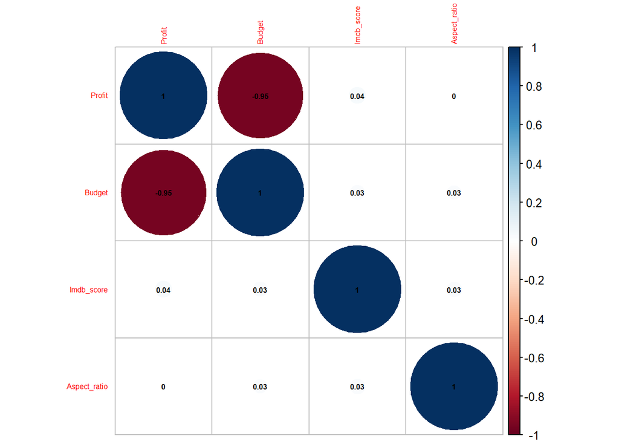

```r
#Swap the columns putting the column variable profit in the front.
dat_mov <- dat_mov[c("Profit","Budget","Imdb_score","Aspect_ratio")]
M <-cor(dat_mov)
corrplot(M,method="circle", addCoef.col = 1,number.cex = 0.5, tl.cex = 0.5)
```

```r
#END TASK 2D
```